# Cyclitic Bike Case study

### Analysis

*Key tasks*

- Aggregate your data so it’s useful and accessible.
- Organize and format your data.
- Perform calculations.
- Identify trends and relationships.

**compare casual and annual riders.**

```r
clean_bike_data%>%group_by(member_casual)%>% summarise(n=n())%>%
  mutate(percentage = n*100/sum(n))
```

```
## # A tibble: 2 × 3
##   member_casual       n percentage
##   <chr>           <int>      <dbl>
## 1 casual        1145633       38.2
## 2 member        1850366       61.8
```

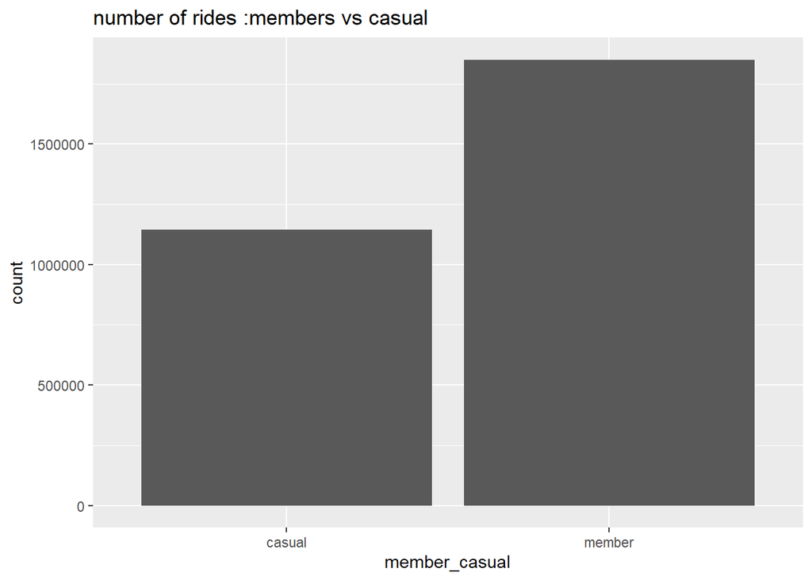

```r
ggplot(clean_bike_data,aes(x=member_casual))+geom_bar()+labs(title = "number of rides :members vs casual")
```

**Graph 1**

from graph 1 above and the table above, we notice that 61.8% of the trips are taken by members and the remaining 38.2% by casual riders.

**compare the average trip duration for both casual and annual riders**

```r
bar <- clean_bike_data%>%group_by(member_casual) %>% summarise(avg_ride_length= mean(trip_duration))
bar
```

```
## # A tibble: 2 × 2
##   member_casual avg_ride_length
##   <chr>         <drtn>
## 1 casual        1937.9871 secs
## 2 member         915.7362 secs
```

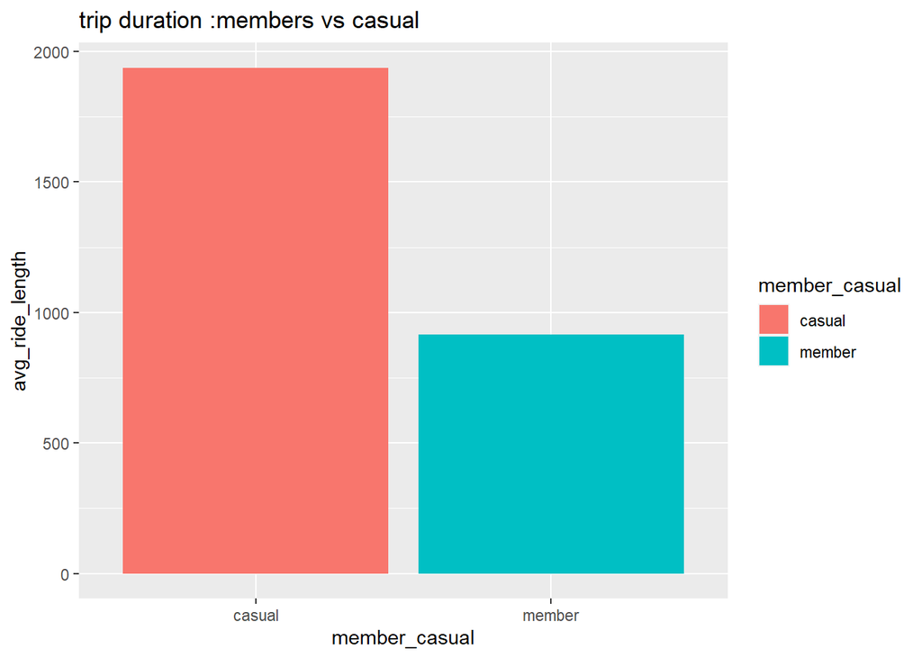

```r
ggplot(bar,aes(x = member_casual,y =avg_ride_length,fill = member_casual))+ geom_col()+labs(title = "trip duration :members vs casual")
```

**Graph 2**

from above, we can see that casual riders spend more time on the bikes compared to members.

**compare bikes types**

```r
bikes <- clean_bike_data%>%group_by(rideable_type)%>%summarise(n=n())%>%
  mutate(percentage = n*100/sum(n))
bikes
```

```
## # A tibble: 3 × 3
##   rideable_type       n percentage
##   <chr>           <int>      <dbl>
## 1 classic_bike   297056       9.92
## 2 docked_bike   2277613      76.0
## 3 electric_bike  421330      14.1
```

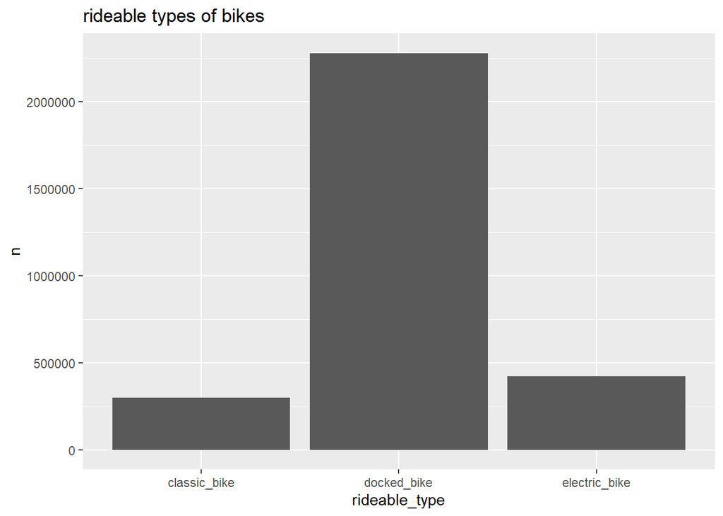

```r
ggplot(bikes,aes(x=rideable_type,y =n ))+geom_col()+labs(title = "rideable types of bikes")
```

**Graph 3**

*From graph 3 above, it’s clear that the company has*

- classic_bike 9.92%
- docked_bike 76.0%
- electric_bike 14.1%

most of which are docked bikes. **the company can use that fact to try and convert casual riders into becoming** **members, but that’s if casual riders use a good potion of that 76%**

**Analyse the choice of bikes by users**

```r
rideable_type <- clean_bike_data %>% group_by(member_casual,rideable_type) %>%
  summarise(n=n())%>%
  mutate(percent = n*100/sum(n))
rideable_type
```

```
## # A tibble: 6 × 4
## # Groups:   member_casual [2]
##   member_casual rideable_type       n percent
##   <chr>         <chr>           <int>   <dbl>
## 1 casual        classic_bike    61116    5.33
## 2 casual        docked_bike    918599   80.2
## 3 casual        electric_bike  165918   14.5
## 4 member        classic_bike   235940   12.8
## 5 member        docked_bike   1359014   73.4
## 6 member        electric_bike  255412   13.8
```

Visual representation for the results above.

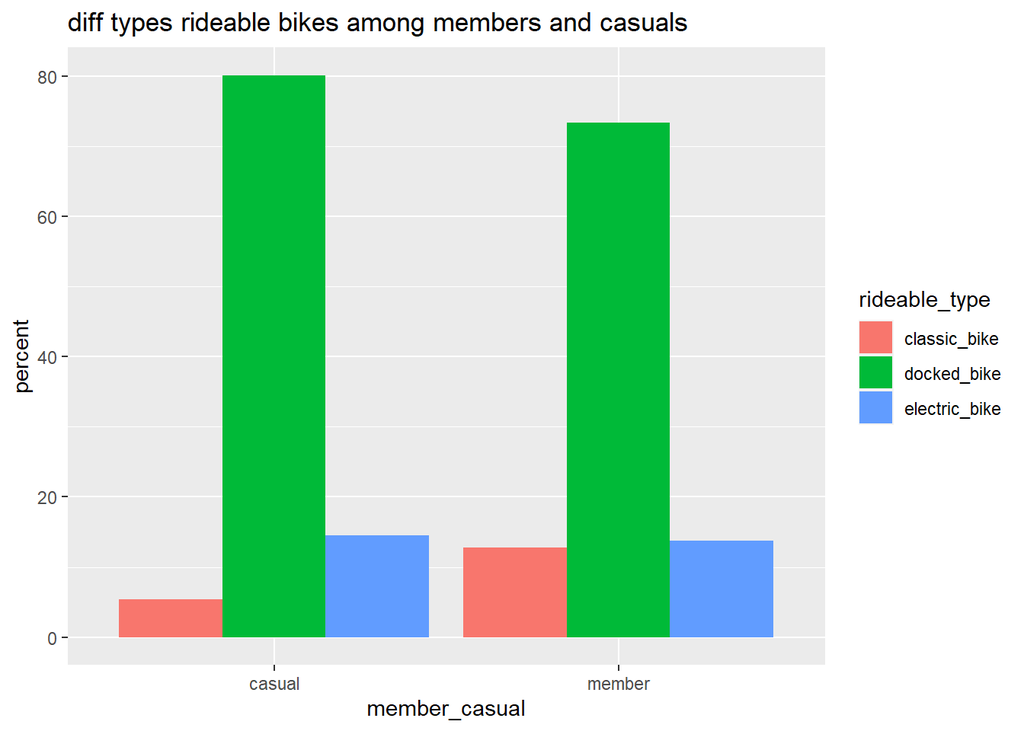

```r
ggplot(rideable_type,aes(x=member_casual,y = percent,fill = rideable_type)) + geom_col(position = "dodge")+labs(title = "diff types rideable bikes among members and casuals")
```

**Graph 4**

From graph 4, we can see that casual riders used docked bikes on 918 599 occasions, which is 80% of the rides they’ve taken. while members on the other hand used docked bikes 1 359 014 times, which is 73.4% of their total number of rides.

from this insight we can see that, **from that 76%** use of docked bikes mentioned above, **40,33%** is used by casual riders and then members use the remaining 59.66% of that … (docked bikes used by casuals/total number of docked bikes)*100 = 40,33%.

the company should then limit the number of docked bikes accessible to casual riders when they need them the most. that decision could make them consider getting annual membership instead.

### DATA VISUALIZATION

Arrange weekdays and months in order

```r
clean_bike_data$weekdays<- factor(clean_bike_data$weekdays, levels= c("Mon", "Tue","Wed","Thu","Fri","Sat","Sun"))
clean_bike_data$months <- factor(clean_bike_data$months, levels = c("Jan","Feb","Mar","Apr","May","Jun","Jul","Aug","Sep","Oct","Nov","Dec"))
```

use of ggplot 2 to count number of trips over a week

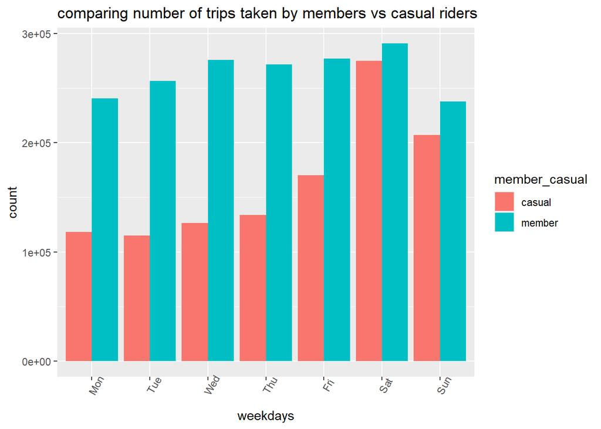

```r
ggplot(clean_bike_data,aes(weekdays,fill = member_casual)) +
  geom_bar(position = "dodge")+
  theme(axis.text.x = element_text(angle = 60))+
  labs(title = "comparing number of trips taken by members vs casual riders", x = "weekdays", y = "count")
```

**Graph 5**

- from above, we can see that members have more trips on an overage day

Now compare the number of trips among users for different bikes to see when casual riders use docked bikes the most

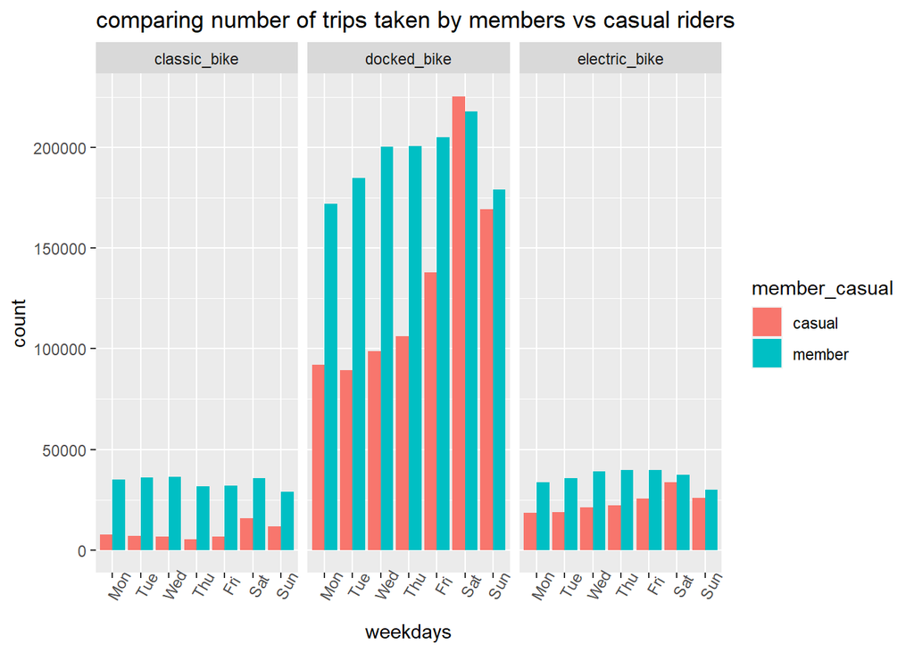

```r
ggplot(clean_bike_data,aes(weekdays,fill = member_casual)) +
  geom_bar(position = "dodge")+
  facet_wrap(~rideable_type)+
  theme(axis.text.x = element_text(angle = 60))+
  labs(title = "comparing number of trips taken by members vs casual riders", x = "weekdays", y = "count")
```

**Graph 6**

**Now lets find out where else can the limit the number of docked bikes accessible to casuals.**

Let’s see at what time of the day do they use these bikes the most.

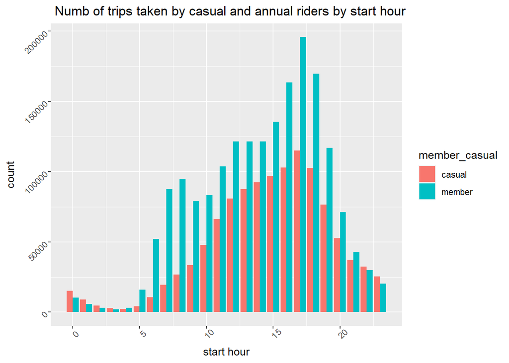

```r
ggplot(clean_bike_data,aes(start_hour,fill = member_casual))+
  geom_bar(position = "dodge")+
  theme(axis.text = element_text(angle =45))+
  labs(title = " Numb of trips taken by casual and annual riders by start hour",x = "start hour",y="count")
```

**graph 7**

We notice the distribution looks similar among these two groups

Now let’s create a plot that groups them by the bikes they use.

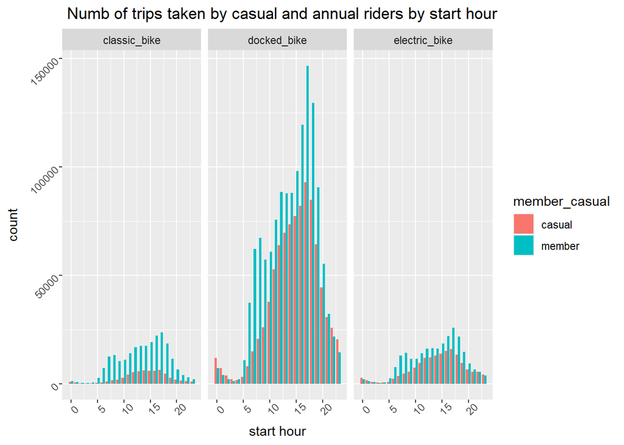

```r
ggplot(clean_bike_data,aes(start_hour,fill = member_casual))+
  geom_bar(position = "dodge")+
  facet_wrap(~rideable_type)+
  theme(axis.text = element_text(angle =45))+
  labs(title = " Numb of trips taken by casual and annual riders by start hour",x = "start hour",y="count")
```

**graph 8**

- From the above plot, we see that there’s a high demand of bikes for both members and casual riders from 16H00 to 18H00.
- For this reason, i would advise that the company should priorities members during this time and limit the number of docked bikes accessible to casual riders because this is where they need them the most.

*Counting the number of trips for both members and casual riders over the past 12 months*

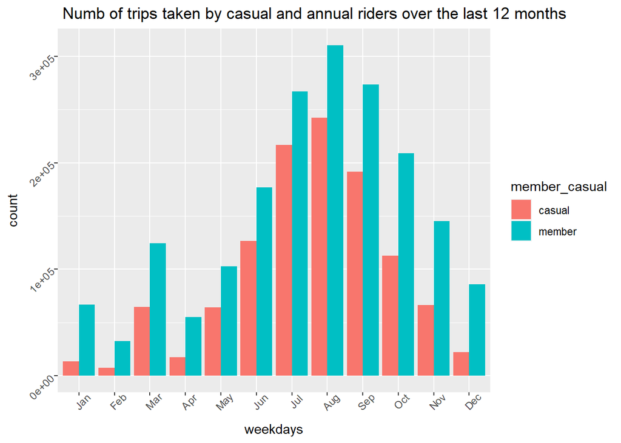

```r
ggplot(clean_bike_data,aes(months,fill = member_casual))+
  geom_bar(position = "dodge")+
  theme(axis.text = element_text(angle =45))+
  labs(title = " Numb of trips taken by casual and annual riders over the last 12 months",x = "weekdays",y="count")
```

**graph 9**

From above we see the distribution looks similar for casual and members.

Compare by rideable type

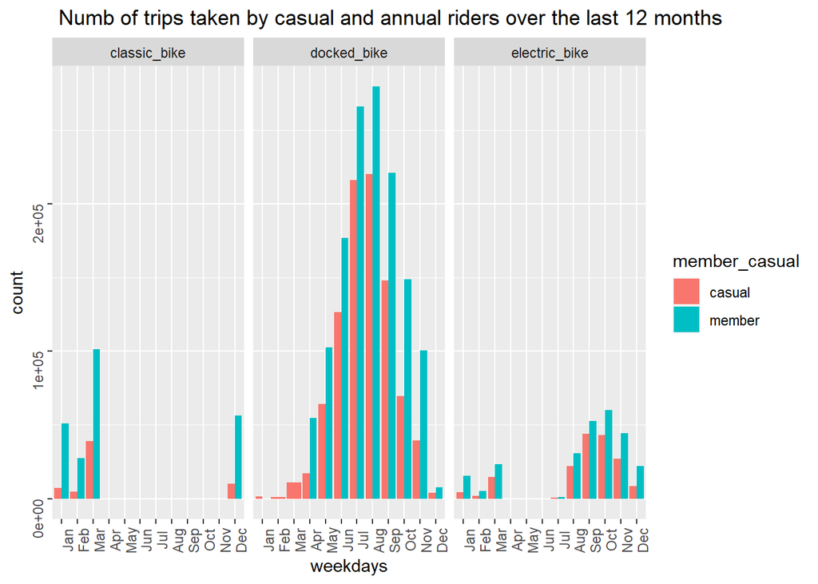

```r
ggplot(clean_bike_data,aes(months,fill = member_casual))+
  geom_bar(position = "dodge")+
  facet_wrap(~rideable_type)+
  theme(axis.text = element_text(angle =90))+
  labs(title = " Numb of trips taken by casual and annual riders over the last 12 months",x = "weekdays",y="count")
```

**graph 10**

Compare the trip distance by casuals and members over a week

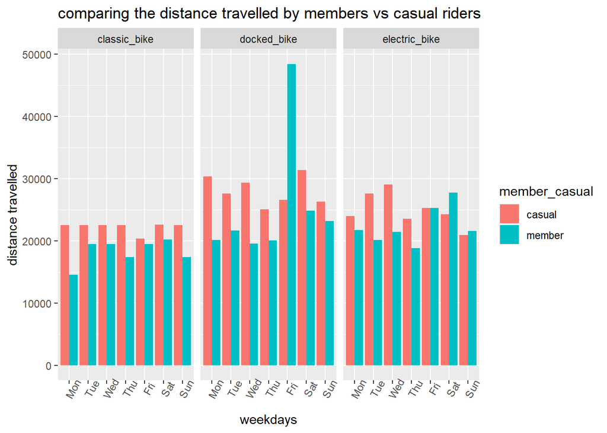

```r
ggplot(clean_bike_data,aes(x=weekdays,y=distance_travelled,fill = member_casual))+
  geom_col(position = "dodge")+
  facet_wrap(~rideable_type)+
  theme(axis.text.x = element_text(angle = 60))+
  labs(title = "comparing the distance travelled by members vs casual riders", x = "weekdays", y = "distance travelled")
```

**Graph 11**

*Now we compare trip duration*

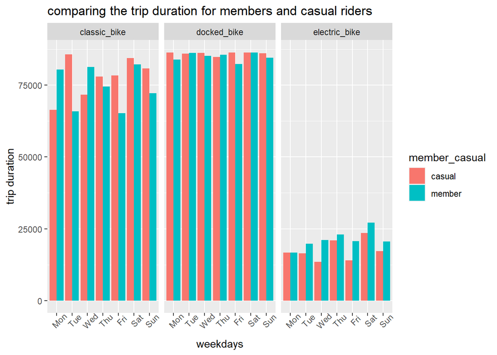

```r
ggplot(clean_bike_data,aes(x=weekdays,y=trip_duration,fill = member_casual))+
  geom_col(position = "dodge")+
  facet_wrap(~rideable_type)+
  theme(axis.text.x = element_text(angle = 45))+
  labs(title = "comparing the trip duration for members and casual riders", x = "weekdays", y = "trip duration")
```

**graph 12**

Now lets see which stations are the most common.(this analysis was done in tableau)

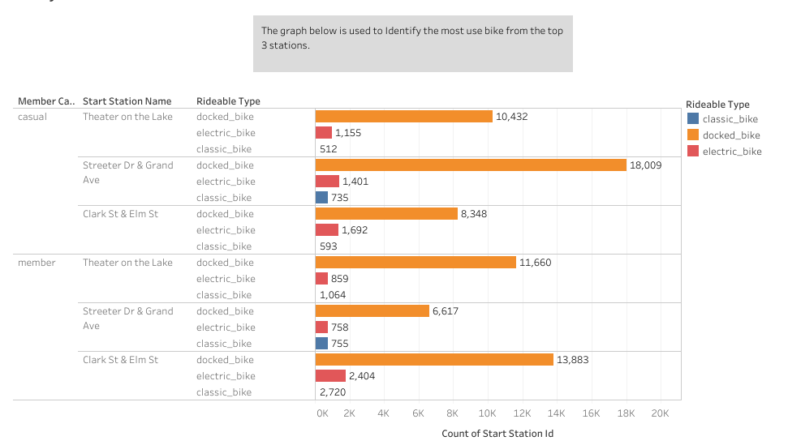

cyclitic bike stations

The graph above shows the analysis from the three most used stations by both casuals and members. from that we see casuals tend to use more docked bike from Streeter Dr & Grand Ave(18 009 rides) than members from any station. docked bikes are mostly used by casual riders on the most popular stations.

## Conclusion

Thanks for Reading, Please provide your feedback.